# Forecasting Insufficient Demand in the Turkish Services Sector

Ömer Faruk ASLANER - 138722028

2026-06-03

```r
packages <- c("dplyr", "stringr", "lubridate", "ggplot2", "forecast", "tibble", "purrr", "tidyr", "knitr", "readr", "tuikr")
missing_packages <- packages[!vapply(packages, requireNamespace, logical(1), quietly = TRUE)]
if (length(missing_packages) > 0) install.packages(missing_packages)
library(dplyr); library(stringr); library(lubridate); library(ggplot2); library(forecast); library(tibble); library(purrr); library(tidyr); library(knitr); library(readr)
source("R/data_import.R")
source("R/accuracy_measures.R")
source("R/forecasting_methods.R")
source("R/plots.R")
dir.create("outputs/figures", recursive = TRUE, showWarnings = FALSE)
dir.create("outputs/tables", recursive = TRUE, showWarnings = FALSE)
```

# 1 Project Overview

This project forecasts the next quarterly value of **insufficient demand** as a factor limiting activities in the Turkish services sector. The selected TÜİK table is **Main factors limiting activities in services sector**, under **Short-Term Economic Indicators**.

# 2 Student Information

- Student name: **Ömer Faruk ASLANER**
- Student number: **138722028**
- Selected variable: **Insufficient demand (%)**

# 3 TÜİK Data Source and Connection

```r
tuik_result <- fetch_tuik_services_insufficient_demand()
series <- tuik_result$data
metadata <- tuik_result$metadata
```

TÜİK data source information

| Field | Value |
| --- | --- |
| Student name | Ömer Faruk ASLANER |
| Student number | 138722028 |
| TÜİK theme/category | Short-Term Economic Indicators |
| Theme ID | 9 |
| TÜİK data set | Main factors limiting activities in services sector |
| TÜİK table name | Main factors limiting activities in services sector |
| tuikr dataflow ID | TR,DF_GUVEN_ENDEKS_FAALIYET_KISITLAMA_SDMX,1.0 |
| Selected variable | Insufficient demand |
| Frequency | Quarterly |
| Unit | Percent (%) |
| Time coverage | 2011-Q1 / 2026-Q2 |
| Number of observations | 62 |
| Latest available observation | 2026-Q2 |
| Forecast target period | 2026-Q3 |
| Data access date | 2026-06-03 |
| Table URL | https://veriportali.tuik.gov.tr/api/tr/data/downloads?t=i&p=PwhiR4B2mkjqk7egH0pxwAc1%2BPTyCszCf9hVoy6ov8PRx8ewVeX%2BhIK4Lq1Z%2BwSnoEdNzxgGOsB5NLhpJAotuiUEq1gaPQ%2BaVUSI3mplWzQ%3D |

**Source note:** The TÜİK istab URL was identified through tuikr::statistical_tables(‘9’), converted from the English API endpoint to the Turkish API endpoint, downloaded during runtime with httr, and read directly into R as a temporary file.

# 4 Use of TÜİK Data in R

The selected table contains several possible limiting factors. In R, the table is reduced to the selected quarterly time series: **insufficient demand**. The period variable is constructed from the year and quarter values. The latest available observation is 2026-Q2, and the next period to forecast is 2026-Q3.

First observations of the selected series

| obsTime | year | quarter | Insufficient demand (%) |
| --- | --- | --- | --- |
| 2011-Q1 | 2011 | Q1 | 31.63983 |
| 2011-Q2 | 2011 | Q2 | 25.80698 |
| 2011-Q3 | 2011 | Q3 | 21.48232 |
| 2011-Q4 | 2011 | Q4 | 27.05746 |
| 2012-Q1 | 2012 | Q1 | 31.43465 |
| 2012-Q2 | 2012 | Q2 | 26.26840 |
| 2012-Q3 | 2012 | Q3 | 25.46190 |
| 2012-Q4 | 2012 | Q4 | 27.51741 |
| 2013-Q1 | 2013 | Q1 | 30.73645 |
| 2013-Q2 | 2013 | Q2 | 29.91272 |
| 2013-Q3 | 2013 | Q3 | 28.39022 |
| 2013-Q4 | 2013 | Q4 | 25.92343 |

# 5 Exploratory Time Series Analysis

Descriptive statistics

| Observations | Minimum | Maximum | Mean | Median | Standard deviation |
| --- | --- | --- | --- | --- | --- |
| 62 | 6.13 | 36.593 | 18.306 | 15.876 | 9.615 |

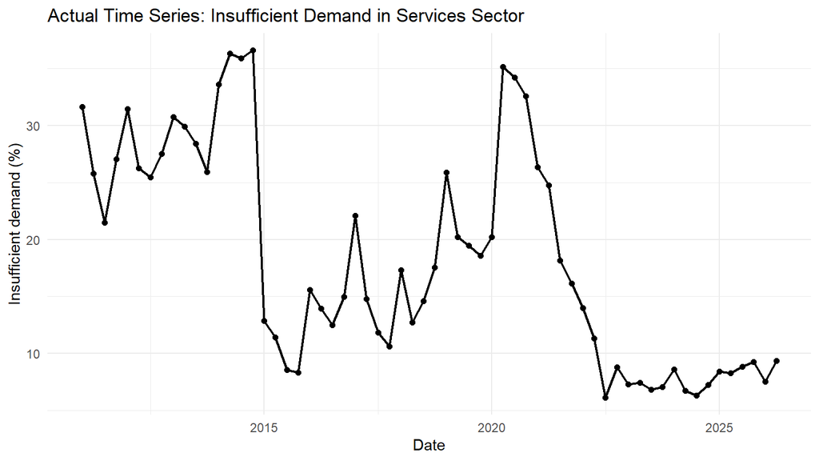

The series is quarterly, so seasonal forecasting methods are applicable. The COVID-19 period also introduces visible volatility, which is considered as a limitation.

# 6 Forecasting Methods Applied

```r
forecast_results <- build_candidate_forecasts(series)
methods <- forecast_results$methods
accuracy <- forecast_results$accuracy
best_method <- accuracy$Method[1]
best_forecast <- accuracy$Next_Period_Forecast[1]
readr::write_csv(accuracy, "outputs/tables/accuracy_comparison.csv")
final_forecast <- tibble::tibble(
  Selected_Superior_Method = best_method,
  Data_Access_Date = metadata$data_access_date,
  Latest_Available_Observation = metadata$latest_available_observation,
  Forecast_Target_Period = metadata$forecast_target_period,
  Forecasted_Value = best_forecast,
  Bias = accuracy$Bias[1],
  MAD = accuracy$MAD[1],
  MSE = accuracy$MSE[1],
  MAPE = accuracy$MAPE[1],
  RSFE = accuracy$RSFE[1],
  Tracking_Signal = accuracy$Tracking_Signal[1]
)
readr::write_csv(final_forecast, "outputs/tables/final_forecast.csv")
save_all_method_plots(series, methods, best_method)
```

The required methods are all considered because the selected series is a positive quarterly time series with sufficient observations for seasonal methods and decomposition.

# 7 Forecast Accuracy Comparison

Forecast accuracy comparison

| Method | Bias | MAD | MSE | MAPE | RSFE | Tracking_Signal | Next_Period_Forecast | Note |
| --- | --- | --- | --- | --- | --- | --- | --- | --- |
| Multiplicative Decomposition | 0.001 | 1.950 | 8.667 | 11.023 | 0.072 | 0.037 | 7.984 | Multiplicative decomposition is considered because the series is positive. |
| Additive Decomposition | -0.003 | 1.907 | 7.796 | 11.136 | -0.201 | -0.105 | 7.984 | Additive decomposition separates trend, seasonal, and random components. |
| Trend-Adjusted Exponential Smoothing | 0.005 | 3.241 | 24.760 | 19.807 | 0.314 | 0.097 | 8.976 | Holt trend-adjusted smoothing with optimized level and trend parameters. |
| Exponential Smoothing | -0.360 | 3.236 | 24.734 | 20.021 | -22.306 | -6.894 | 9.338 | Simple exponential smoothing with optimized alpha. |
| Naive Forecasting | -0.366 | 3.289 | 25.139 | 20.349 | -22.302 | -6.782 | 9.338 | Previous quarter value is used as the next forecast. |
| Weighted Moving Average | -0.575 | 4.029 | 35.185 | 26.921 | -33.339 | -8.274 | 8.729 | Recent quarters receive larger weights: 0.10, 0.20, 0.30, 0.40. |
| Moving Average | -0.727 | 4.502 | 43.783 | 31.235 | -42.159 | -9.364 | 8.745 | Four-quarter moving average is used because the data are quarterly. |
| Regression with Trend and Seasonal Dummies | 0.000 | 5.481 | 52.162 | 36.579 | 0.000 | 0.000 | 6.213 | Regression uses a time trend and quarterly seasonal dummy variables. |
| Linear Trend Projection | 0.000 | 5.539 | 52.888 | 36.884 | 0.000 | 0.000 | 7.444 | Trend equation: y = 29.167 + -0.345t. |
| Seasonal Indices | 0.000 | 8.324 | 90.211 | 62.215 | 0.000 | 0.000 | 17.247 | Quarterly seasonal indices: 1 1.071; 2 1.005; 3 0.942; 4 0.977 |

# 8 Actual vs Forecast Plots

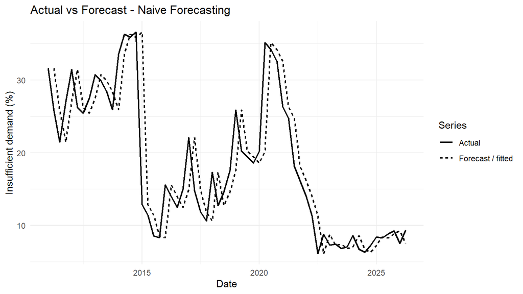

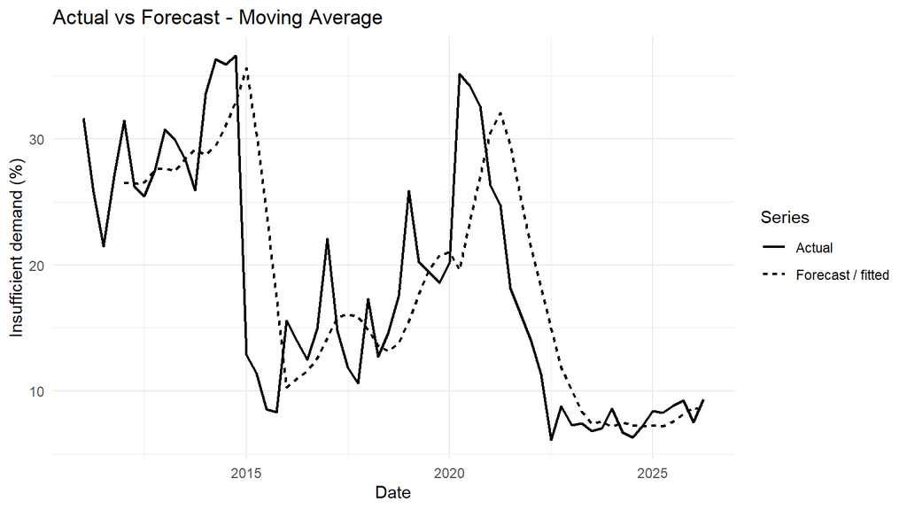

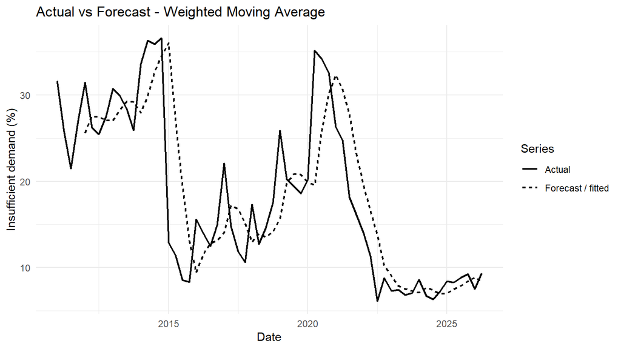

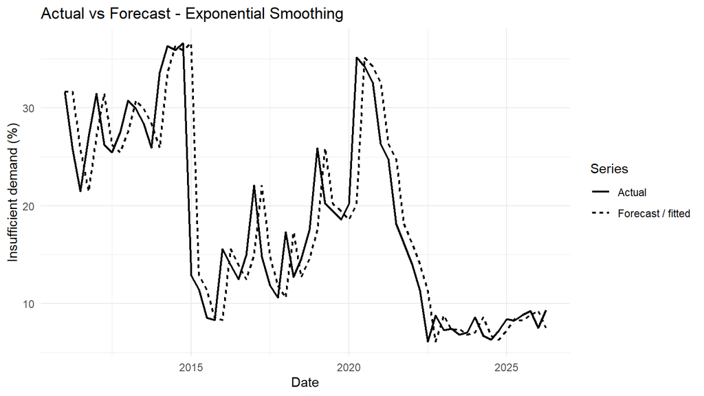

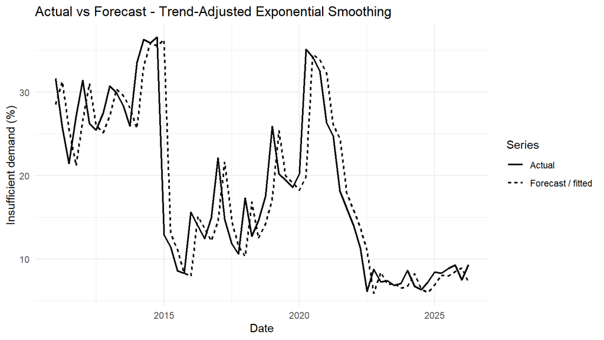

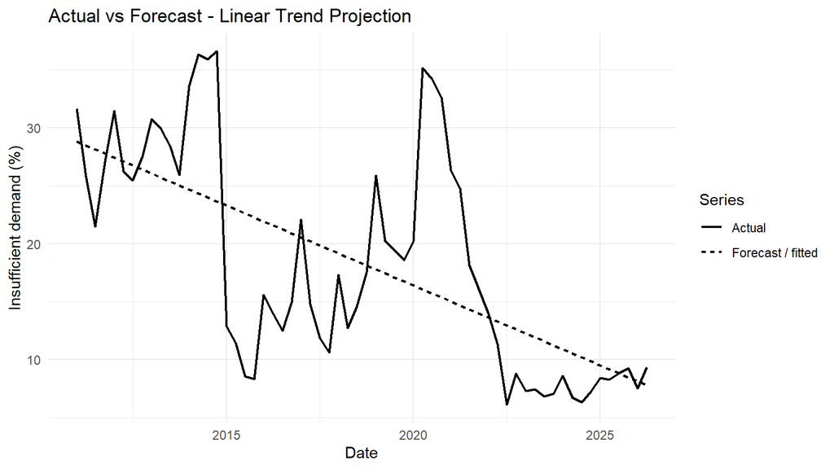